# R Notebook

### Dataset

This dataset contains 69,533 observations of 77 variables of 35 are integers over 25 are characters and almost 15 are numeric. It is a very large dataset so; I did not think that extracting just the information that I need ahead of time would not be a good idea. for now, I have decided to look at all data and pick through as well as clean the data separately. for that I think that using some generalization and getting a snapshot of what I have will yield me good insight on which questions to ask.

```r
library(dplyr)
df <- read.csv("C:/Users/jeffb/OneDrive/Desktop/WSU-Spring-2022/Big Data Analitics/data-capstone-final-project/nysus.csv")

head(df)
```

|  | Date.Created | Borough | Map.Atlas | Block | Lot | Address | Street.Number | Street.Name | Parcel.Name | Agency | Current.Uses | Total.Area | Open.Petroleum.Spill | Govt.Clean.Up.Program | Structure.Completed | Number.Structures | Total.Gross.Area.Structures | Ratio.Building.to.Floor.Area | Allowable.Building.to.Floor.Area | Land.Use.Category | Community.Board | Census.Tract | Census.Block | School.Dist | Council.District | Postcode | Fire.Comp | Health.Area | Health.Ctr | … |
| --- | --- | --- | --- | --- | --- | --- | --- | --- | --- | --- | --- | --- | --- | --- | --- | --- | --- | --- | --- | --- | --- | --- | --- | --- | --- | --- | --- | --- | --- | --- |
| 1 | 10/10/2019 | 1 | NA | 2 | 1 | 4 SOUTH STREET | 4 | SOUTH STREET | SI FERRY TERMINAL | DOT;DSBS | FERRY TERMINAL;NO USE;WATERFRONT PROPERTY | 209215 |  |  | 1908 | 2 | 280000 | 1.34 | 6.5 | 7 | 101 | 9 | 1025 | 2 | 1 | 10004 | L015 | 7700 | 15 | … |
| 2 | 10/10/2019 | 1 | NA | 2 | 2 | 10 SOUTH STREET | 10 | SOUTH STREET | BATTERY MARITIME BLDG | DSBS | IN USE-TENANTED;LONG-TERM AGREEMENT;WATERFRONT PROPERTY | 191502 |  |  | 1900 | 1 | 158197 | 0.83 | 10.0 | 7 | 101 | 9 | 1025 | 2 | 1 | 10004 | L015 | 7700 | 15 | … |
| 3 | 10/10/2019 | 1 | NA | 2 | 3 | MARGINAL STREET |  | MARGINAL STREET | MTA SUBSTATION | DSBS | NO USE-NON RES STRC;TRANSIT SUBSTATION | 38800 |  |  | 1900 | 1 | 7500 | 0.19 | 10.0 | 7 | 101 | 9 | 1 | NA | 1 | NA |  | NA | NA | … |
| 4 | 10/10/2019 | 1 | NA | 2 | 23 | 1 PIER 6 | 1 | PIER 6 | PIER 6 | DSBS | IN USE-TENANTED;FINAL COMMITMNT-DISP;LONG-TERM AGREEMENT;NO USE;FINAL COMMITMNT-DISP | 510025 |  |  | 1987 | 1 | 24346 | 0.05 | 10.0 | 7 | 101 | 9 | 1025 | 2 | 1 | 10004 | L015 | 7700 | 15 | … |
| 5 | 10/10/2019 | 1 | NA | 3 | 1 | 10 BATTERY PARK | 10 | BATTERY PARK | BATTERY PARK | PARKS | PARK | 945425 |  |  | 1951 | 6 | 945425 | 1.00 | 0.0 | 9 | 101 | 13 | 2005 | 2 | 1 | 10004 | E010 | 7700 | 15 | … |
| 6 | 10/10/2019 | 1 | NA | 3 | 2 | PETER MINUIT PLAZA |  | PETER MINUIT PLAZA | PETER MINUIT PLAZA/BATTERY PK | PARKS | PARK | 39900 |  |  | 0 | 3 | 0 | 0.00 | 0.0 | 9 | 101 | 9 | 1023 | 2 | 1 | 10004 | L015 | 7700 | 15 | … |

This bar plot shows the types of data I have. this data probably contains a lot of good data to group by. another important aspect of this dataset is that it can generate good geographical analysis, timeseries as well as other classifications and regressions.

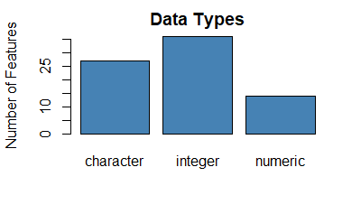

```r
data_types <- function(frame) {
  res <- lapply(frame, class)
  res_frame <- data.frame(unlist(res))
  barplot(table(res_frame), main="Data Types", col="steelblue", ylab="Number of Features")
}

data_types(df)
```

```r
names(df)
```

```
 [1] "Date.Created"                          "Borough"                               "Map.Atlas"                             "Block"
 [5] "Lot"                                   "Address"                               "Street.Number"                         "Street.Name"
 [9] "Parcel.Name"                           "Agency"                                "Current.Uses"                          "Total.Area"
[13] "Open.Petroleum.Spill"                  "Govt.Clean.Up.Program"                 "Structure.Completed"                   "Number.Structures"
[17] "Total.Gross.Area.Structures"           "Ratio.Building.to.Floor.Area"          "Allowable.Building.to.Floor.Area"      "Land.Use.Category"
[21] "Community.Board"                       "Census.Tract"                          "Census.Block"                          "School.Dist"
[25] "Council.District"                      "Postcode"                              "Fire.Comp"                             "Health.Area"
[29] "Health.Ctr"                            "Police.Prct"                           "Major.Use"                             "Number.of.Easements"
[33] "Commercial.Floor.Area"                 "Residential.Floor.Area"                "Office.Floor.Area"                     "Retail.Floor.Area"
[37] "Garage.Floor.Area"                     "Storage.Floor.Area"                    "Factory.Floor.Area"                    "Other.Floor.Area"
[41] "Num.Floors"                            "Residential.Units"                     "Residential.and.Non.Residential.Units" "Lot.Front"
[45] "Lot.Depth"                             "Bldg.Front"                            "Bldg.Depth"                            "Proximity.Code"
[49] "Irr.Lot.Code"                          "Lot.Type.Code"                         "Bsmt.Code"                             "Assess.Land"
[53] "Exempt.Land"                           "Exempt.Tot"                            "Year.Alter.1"                          "Year.Alter.2"
[57] "His.Dist"                              "Landmark"                              "Condominium.Number"                    "Coordinates"
[61] "E.Designation.Number"                  "Industrial.Business.Zone"              "Zone.Dist.1"                           "Zone.Dist.2"
[65] "Overlay.1"                             "Overlay.2"                             "SP.Dist.1"                             "SP.Dist.2"
[69] "Potential.Urban.Ag"                    "Contact"                               "EDC...Occupied"                        "Pluto.Version"
[73] "Latitude"                              "Longitude"                             "BIN"                                   "BBL"
[77] "NTA"
```

```r
library("reshape2")
library(ggplot2)

par(mfrow = c(1, 2))

data_long <- melt(df)                                      # Reshaping data frame
```

```
Using Date.Created, Address, Street.Number, Street.Name, Parcel.Name, Agency, Current.Uses, Open.Petroleum.Spill, Govt.Clean.Up.Program, Fire.Comp, Major.Use, Irr.Lot.Code, His.Dist, Landmark, Coordinates, E.Designation.Number, Industrial.Business.Zone, Zone.Dist.1, Zone.Dist.2, Overlay.1, Overlay.2…
```

[figure not shown]

```r
#head(data_long)
ggplot(data_long, aes(x = variable, y = value)) +            # Applying ggplot function
  geom_boxplot() +
  scale_x_discrete(guide = guide_axis(angle = 90))
```

```r
col1 <- c('Assess.Land', 'Exempt.Land', 'Exempt.Tot', 'BBL')
df1 <- df[!(names(df)) %in% col]

#removing columns with large numbers
data_long <- melt(df1)                                      # Reshaping data frame
```

```
Using Date.Created, Address, Street.Number, Street.Name, Parcel.Name, Agency, Current.Uses, Open.Petroleum.Spill, Govt.Clean.Up.Program, Fire.Comp, Major.Use, Irr.Lot.Code, His.Dist, Landmark, Coordinates, E.Designation.Number, Industrial.Business.Zone, Zone.Dist.1, Zone.Dist.2, Overlay.1, Overlay.2…
```

```r
#head(data_long)
ggplot(data_long, aes(x = variable, y = value)) +            # Applying ggplot function
  geom_boxplot() +
  scale_x_discrete(guide = guide_axis(angle = 90))
par(mfrow = c(1, 2))
```

[output not shown]

```r
col2 <- c('Total.Area')
df2 <- df1[!(names(df1)) %in% col]

#removing columns with large numbers
data_long <- melt(df2)                                      # Reshaping data frame
```

```
Using Date.Created, Address, Street.Number, Street.Name, Parcel.Name, Agency, Current.Uses, Open.Petroleum.Spill, Govt.Clean.Up.Program, Fire.Comp, Major.Use, Irr.Lot.Code, His.Dist, Landmark, Coordinates, E.Designation.Number, Industrial.Business.Zone, Zone.Dist.1, Zone.Dist.2, Overlay.1, Overlay.2…
```

```r
#head(data_long)
ggplot(data_long, aes(x = variable, y = value)) +            # Applying ggplot function
  geom_boxplot() +
  scale_x_discrete(guide = guide_axis(angle = 90))
col3 <- c('Total.Gross.Area.Structures', 'Commercial.Floor.Area', 'Other.Floor.Area', 'BIN')
df3 <- df2[!(names(df2)) %in% col]

#removing columns with large numbers
data_long <- melt(df3)                                      # Reshaping data frame
```

```
Using Date.Created, Address, Street.Number, Street.Name, Parcel.Name, Agency, Current.Uses, Open.Petroleum.Spill, Govt.Clean.Up.Program, Fire.Comp, Major.Use, Irr.Lot.Code, His.Dist, Landmark, Coordinates, E.Designation.Number, Industrial.Business.Zone, Zone.Dist.1, Zone.Dist.2, Overlay.1, Overlay.2…
```

```r
head(data_long)
```

|  | Date.Created | Address | Street.Number | Street.Name | Parcel.Name | Agency | Current.Uses | Open.Petroleum.Spill | Govt.Clean.Up.Program | Fire.Comp | Major.Use | Irr.Lot.Code | His.Dist | Landmark | Coordinates | E.Designation.Number | Industrial.Business.Zone | Zone.Dist.1 | Zone.Dist.2 | Overlay.1 | Overlay.2 | SP.Dist.1 | SP.Dist.2 | Potential.Urban.Ag | Contact | Pluto.Version | NTA | variable | value |
| --- | --- | --- | --- | --- | --- | --- | --- | --- | --- | --- | --- | --- | --- | --- | --- | --- | --- | --- | --- | --- | --- | --- | --- | --- | --- | --- | --- | --- | --- |
| 1 | 10/10/2019 | 4 SOUTH STREET | 4 | SOUTH STREET | SI FERRY TERMINAL | DOT;DSBS | FERRY TERMINAL;NO USE;WATERFRONT PROPERTY |  |  | L015 | Y7 | Y |  |  | 980670/194440 |  |  | M1-4 |  |  |  | LM |  |  | Saundra Malanowicz (212)386-0612 smalanowicz@dcas.nyc.gov | 19v1 | Battery Park City-Lower Manhattan | Borough | 1 |
| 2 | 10/10/2019 | 10 SOUTH STREET | 10 | SOUTH STREET | BATTERY MARITIME BLDG | DSBS | IN USE-TENANTED;LONG-TERM AGREEMENT;WATERFRONT PROPERTY |  |  | L015 | Y7 | Y |  | INDIVIDUAL LANDMARK | 981037/194506 |  |  | C4-6 |  |  |  | LM |  |  | Saundra Malanowicz (212)386-0612 smalanowicz@dcas.nyc.gov | 19v1 | Battery Park City-Lower Manhattan | Borough | 1 |
| 3 | 10/10/2019 | MARGINAL STREET |  | MARGINAL STREET | MTA SUBSTATION | DSBS | NO USE-NON RES STRC;TRANSIT SUBSTATION |  |  |  | Y7 | N |  |  | 981224/194590 |  |  | C4-6 |  |  |  | LM |  |  | Saundra Malanowicz (212)386-0612 smalanowicz@dcas.nyc.gov | 19v1 | Battery Park City-Lower Manhattan | Borough | 1 |
| 4 | 10/10/2019 | 1 PIER 6 | 1 | PIER 6 | PIER 6 | DSBS | IN USE-TENANTED;FINAL COMMITMNT-DISP;LONG-TERM AGREEMENT;NO USE;FINAL COMMITMNT-DISP |  |  | L015 | T2 | Y |  |  | 981687/194732 |  |  | C4-6 |  |  |  | LM |  |  | Saundra Malanowicz (212)386-0612 smalanowicz@dcas.nyc.gov | 19v1 | Battery Park City-Lower Manhattan | Borough | 1 |
| 5 | 10/10/2019 | 10 BATTERY PARK | 10 | BATTERY PARK | BATTERY PARK | PARKS | PARK |  |  | E010 | Q1 | Y |  | INDIVIDUAL LANDMARK | 979916/195328 |  |  | PARK |  |  |  |  |  |  | Saundra Malanowicz (212)386-0612 smalanowicz@dcas.nyc.gov | 19v1 | Battery Park City-Lower Manhattan | Borough | 1 |
| 6 | 10/10/2019 | PETER MINUIT PLAZA |  | PETER MINUIT PLAZA | PETER MINUIT PLAZA/BATTERY PK | PARKS | PARK |  |  | L015 | Q1 | Y |  |  | 980470/194954 |  |  | PARK | C5-5 |  |  | LM |  |  | Saundra Malanowicz (212)386-0612 smalanowicz@dcas.nyc.gov | 19v1 | Battery Park City-Lower Manhattan | Borough | 1 |

```r
ggplot(data_long, aes(x = variable, y = value)) +            # Applying ggplot function
  geom_boxplot() +
  scale_x_discrete(guide = guide_axis(angle = 90))
par(mfrow = c(1, 2))
```

[output not shown]

```r
col4 <- c('Residential.Floor.Area', 'Office.Floor.Area', 'Retail.Floor.Area', 'Garage.Floor.Area', 'Storage.Floor.Area', 'Factory.Floor.Area')
df4 <- df3[!(names(df3)) %in% col]

#removing columns with large numbers
data_long <- melt(df4)                                      # Reshaping data frame
```

```
Using Date.Created, Address, Street.Number, Street.Name, Parcel.Name, Agency, Current.Uses, Open.Petroleum.Spill, Govt.Clean.Up.Program, Fire.Comp, Major.Use, Irr.Lot.Code, His.Dist, Landmark, Coordinates, E.Designation.Number, Industrial.Business.Zone, Zone.Dist.1, Zone.Dist.2, Overlay.1, Overlay.2…
```

```r
#head(data_long)
ggplot(data_long, aes(x = variable, y = value)) +            # Applying ggplot function
  geom_boxplot() +
  scale_x_discrete(guide = guide_axis(angle = 90))
col5 <- c('Block', 'Lot', 'Structure.Completed', 'Census.Block', 'Census.Tract', 'Postcode', 'Health.Area', 'Residential.Units', 'Residential.and.Non.Residential.Units', 'Lot.Front', 'Lot.Depth', 'Bldg.Front', 'Bldg.Depth', 'Condominium.Number')
df5 <- df4[!(names(df4)) %in% col]

#removing columns with large numbers
data_long <- melt(df5)                                      # Reshaping data frame
```

```
Using Date.Created, Address, Street.Number, Street.Name, Parcel.Name, Agency, Current.Uses, Open.Petroleum.Spill, Govt.Clean.Up.Program, Fire.Comp, Major.Use, Irr.Lot.Code, His.Dist, Landmark, Coordinates, E.Designation.Number, Industrial.Business.Zone, Zone.Dist.1, Zone.Dist.2, Overlay.1, Overlay.2…
```

```r
#head(data_long)
ggplot(data_long, aes(x = variable, y = value)) +            # Applying ggplot function
  geom_boxplot() +
  scale_x_discrete(guide = guide_axis(angle = 90))
par(mfrow = c(1, 2))
```

[output not shown]

```r
col6 <- c('Year.Alter.1', 'Year.Alter.2')
df6 <- df5[!(names(df5)) %in% col]

#removing columns with large numbers
data_long <- melt(df6)                                      # Reshaping data frame
```

```
Using Date.Created, Address, Street.Number, Street.Name, Parcel.Name, Agency, Current.Uses, Open.Petroleum.Spill, Govt.Clean.Up.Program, Fire.Comp, Major.Use, Irr.Lot.Code, His.Dist, Landmark, Coordinates, E.Designation.Number, Industrial.Business.Zone, Zone.Dist.1, Zone.Dist.2, Overlay.1, Overlay.2…
```

```r
#head(data_long)
ggplot(data_long, aes(x = variable, y = value)) +            # Applying ggplot function
  geom_boxplot() +
  scale_x_discrete(guide = guide_axis(angle = 90))
col7 <- c('Number.Structures', 'Ratio.Building.to.Floor.Area', 'Community.Board')
df7 <- df6[!(names(df6)) %in% col]

#removing columns with large numbers
data_long <- melt(df7)                                      # Reshaping data frame
```

```
Using Date.Created, Address, Street.Number, Street.Name, Parcel.Name, Agency, Current.Uses, Open.Petroleum.Spill, Govt.Clean.Up.Program, Fire.Comp, Major.Use, Irr.Lot.Code, His.Dist, Landmark, Coordinates, E.Designation.Number, Industrial.Business.Zone, Zone.Dist.1, Zone.Dist.2, Overlay.1, Overlay.2…
```

```r
#head(data_long)
ggplot(data_long, aes(x = variable, y = value)) +            # Applying ggplot function
  geom_boxplot() +
  scale_x_discrete(guide = guide_axis(angle = 90))
par(mfrow = c(1, 2))
```

[output not shown]

```r
col8 <- c('Longitude', 'Latitude')
df8 <- df7[!(names(df7)) %in% col]

#removing columns with large numbers
data_long <- melt(df8)                                      # Reshaping data frame
```

```
Using Date.Created, Address, Street.Number, Street.Name, Parcel.Name, Agency, Current.Uses, Open.Petroleum.Spill, Govt.Clean.Up.Program, Fire.Comp, Major.Use, Irr.Lot.Code, His.Dist, Landmark, Coordinates, E.Designation.Number, Industrial.Business.Zone, Zone.Dist.1, Zone.Dist.2, Overlay.1, Overlay.2…
```

```r
#head(data_long)
ggplot(data_long, aes(x = variable, y = value)) +            # Applying ggplot function
  geom_boxplot() +
  scale_x_discrete(guide = guide_axis(angle = 90))
```

[output not shown]

to put this dataset to the test i ran boxplot of all varibles and was able to verify that 4 values stood out with outstanding values. I decided then to investigate them individually.

```r
col = c("Assess.Land", "Exempt.Land", "Exempt.Tot", "BBL")
df1 <- df[,col]
df1
```

| Assess.Land | Exempt.Land | Exempt.Tot | BBL |
| --- | --- | --- | --- |
| 18818100 | NA | 35179200 | 1000020001 |
| 18787500 | NA | 26151750 | 1000020002 |
| 735750 | NA | 898200 | 1000020003 |
| 15255450 | NA | 18723600 | 1000020023 |
| 127100700 | NA | 141688800 | 1000030001 |
| 5060250 | NA | 5060250 | 1000030002 |
| 4803750 | NA | 4803750 | 1000030003 |
| 28312650 | NA | 28312650 | 1000060001 |
| 7875000 | NA | 0 | 1000100014 |
| 6789150 | NA | 6789150 | 1000120028 |

[output cut: 990 more lines]

```r
data_long <- melt(df1)                                      # Reshaping data frame
head(data_long)
```

|  | variable | value |
| --- | --- | --- |
| 1 | Assess.Land | 18818100 |
| 2 | Assess.Land | 18787500 |
| 3 | Assess.Land | 735750 |
| 4 | Assess.Land | 15255450 |
| 5 | Assess.Land | 127100700 |
| 6 | Assess.Land | 5060250 |

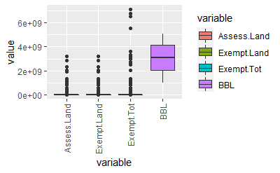

```r
ggplot(data_long, aes(x = variable, y = value, fill = variable)) +            # Applying ggplot function
  geom_boxplot() +
  scale_x_discrete(guide = guide_axis(angle = 90))
```

the values for Assess.Land, Exempt.Land and Exempt.Land are squashed at the bottom. this makes for a data set hard to visualize.

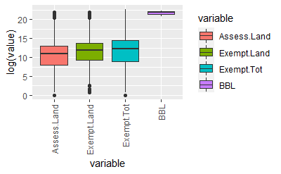

```r
ggplot(data_long, aes(x = variable, y = log(value), fill = variable)) +            # Applying ggplot function
  geom_boxplot() +
  scale_x_discrete(guide = guide_axis(angle = 90))
```

using a log tranformation on the y value helps bring the first three varibles to a better perspective but BBL does not fare as nicely. so it is best to look at all the variables separetly.

```r
col = c("Assess.Land", "Exempt.Land", "Exempt.Tot")
df1 <- df[,col]
df1
```

| Assess.Land | Exempt.Land | Exempt.Tot |
| --- | --- | --- |
| 18818100 | NA | 35179200 |
| 18787500 | NA | 26151750 |
| 735750 | NA | 898200 |
| 15255450 | NA | 18723600 |
| 127100700 | NA | 141688800 |
| 5060250 | NA | 5060250 |
| 4803750 | NA | 4803750 |
| 28312650 | NA | 28312650 |
| 7875000 | NA | 0 |
| 6789150 | NA | 6789150 |

[output cut: 990 more lines]

```r
data_long <- melt(df1)                                      # Reshaping data frame
head(data_long)
```

|  | variable | value |
| --- | --- | --- |
| 1 | Assess.Land | 18818100 |
| 2 | Assess.Land | 18787500 |
| 3 | Assess.Land | 735750 |
| 4 | Assess.Land | 15255450 |
| 5 | Assess.Land | 127100700 |
| 6 | Assess.Land | 5060250 |

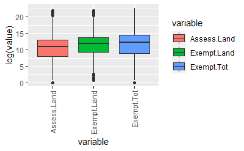

```r
ggplot(data_long, aes(x = variable, y = log(value), fill = variable)) +            # Applying ggplot function
  geom_boxplot() +
  scale_x_discrete(guide = guide_axis(angle = 90))
```

I can now see that they have some resemblance and share some regularity but I need to truly see what this values mean.

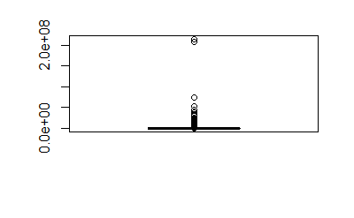

```r
boxplot(df$Total.Area)
```

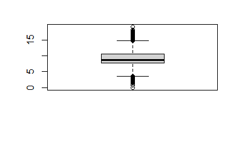

```r
boxplot(log(df$Total.Area))
```

CLASSIFICATION

```r
head(df)
```

|  | Date.Created | Borough | Map.Atlas | Block | Lot | Address | Street.Number | Street.Name | Parcel.Name | Agency | Current.Uses | Total.Area | Open.Petroleum.Spill | Govt.Clean.Up.Program | Structure.Completed | Number.Structures | Total.Gross.Area.Structures | Ratio.Building.to.Floor.Area | Allowable.Building.to.Floor.Area | Land.Use.Category | Community.Board | Census.Tract | Census.Block | School.Dist | Council.District | Postcode | Fire.Comp | Health.Area | Health.Ctr | … |
| --- | --- | --- | --- | --- | --- | --- | --- | --- | --- | --- | --- | --- | --- | --- | --- | --- | --- | --- | --- | --- | --- | --- | --- | --- | --- | --- | --- | --- | --- | --- |
| 1 | 10/10/2019 | 1 | NA | 2 | 1 | 4 SOUTH STREET | 4 | SOUTH STREET | SI FERRY TERMINAL | DOT;DSBS | FERRY TERMINAL;NO USE;WATERFRONT PROPERTY | 209215 |  |  | 1908 | 2 | 280000 | 1.34 | 6.5 | 7 | 101 | 9 | 1025 | 2 | 1 | 10004 | L015 | 7700 | 15 | … |
| 2 | 10/10/2019 | 1 | NA | 2 | 2 | 10 SOUTH STREET | 10 | SOUTH STREET | BATTERY MARITIME BLDG | DSBS | IN USE-TENANTED;LONG-TERM AGREEMENT;WATERFRONT PROPERTY | 191502 |  |  | 1900 | 1 | 158197 | 0.83 | 10.0 | 7 | 101 | 9 | 1025 | 2 | 1 | 10004 | L015 | 7700 | 15 | … |
| 3 | 10/10/2019 | 1 | NA | 2 | 3 | MARGINAL STREET |  | MARGINAL STREET | MTA SUBSTATION | DSBS | NO USE-NON RES STRC;TRANSIT SUBSTATION | 38800 |  |  | 1900 | 1 | 7500 | 0.19 | 10.0 | 7 | 101 | 9 | 1 | NA | 1 | NA |  | NA | NA | … |
| 4 | 10/10/2019 | 1 | NA | 2 | 23 | 1 PIER 6 | 1 | PIER 6 | PIER 6 | DSBS | IN USE-TENANTED;FINAL COMMITMNT-DISP;LONG-TERM AGREEMENT;NO USE;FINAL COMMITMNT-DISP | 510025 |  |  | 1987 | 1 | 24346 | 0.05 | 10.0 | 7 | 101 | 9 | 1025 | 2 | 1 | 10004 | L015 | 7700 | 15 | … |
| 5 | 10/10/2019 | 1 | NA | 3 | 1 | 10 BATTERY PARK | 10 | BATTERY PARK | BATTERY PARK | PARKS | PARK | 945425 |  |  | 1951 | 6 | 945425 | 1.00 | 0.0 | 9 | 101 | 13 | 2005 | 2 | 1 | 10004 | E010 | 7700 | 15 | … |
| 6 | 10/10/2019 | 1 | NA | 3 | 2 | PETER MINUIT PLAZA |  | PETER MINUIT PLAZA | PETER MINUIT PLAZA/BATTERY PK | PARKS | PARK | 39900 |  |  | 0 | 3 | 0 | 0.00 | 0.0 | 9 | 101 | 9 | 1023 | 2 | 1 | 10004 | L015 | 7700 | 15 | … |

```r
head(df[-1])
```

|  | Borough | Map.Atlas | Block | Lot | Address | Street.Number | Street.Name | Parcel.Name | Agency | Current.Uses | Total.Area | Open.Petroleum.Spill | Govt.Clean.Up.Program | Structure.Completed | Number.Structures | Total.Gross.Area.Structures | Ratio.Building.to.Floor.Area | Allowable.Building.to.Floor.Area | Land.Use.Category | Community.Board | Census.Tract | Census.Block | School.Dist | Council.District | Postcode | Fire.Comp | Health.Area | Health.Ctr | Police.Prct | … |
| --- | --- | --- | --- | --- | --- | --- | --- | --- | --- | --- | --- | --- | --- | --- | --- | --- | --- | --- | --- | --- | --- | --- | --- | --- | --- | --- | --- | --- | --- | --- |
| 1 | 1 | NA | 2 | 1 | 4 SOUTH STREET | 4 | SOUTH STREET | SI FERRY TERMINAL | DOT;DSBS | FERRY TERMINAL;NO USE;WATERFRONT PROPERTY | 209215 |  |  | 1908 | 2 | 280000 | 1.34 | 6.5 | 7 | 101 | 9 | 1025 | 2 | 1 | 10004 | L015 | 7700 | 15 | 1 | … |
| 2 | 1 | NA | 2 | 2 | 10 SOUTH STREET | 10 | SOUTH STREET | BATTERY MARITIME BLDG | DSBS | IN USE-TENANTED;LONG-TERM AGREEMENT;WATERFRONT PROPERTY | 191502 |  |  | 1900 | 1 | 158197 | 0.83 | 10.0 | 7 | 101 | 9 | 1025 | 2 | 1 | 10004 | L015 | 7700 | 15 | 1 | … |
| 3 | 1 | NA | 2 | 3 | MARGINAL STREET |  | MARGINAL STREET | MTA SUBSTATION | DSBS | NO USE-NON RES STRC;TRANSIT SUBSTATION | 38800 |  |  | 1900 | 1 | 7500 | 0.19 | 10.0 | 7 | 101 | 9 | 1 | NA | 1 | NA |  | NA | NA | NA | … |
| 4 | 1 | NA | 2 | 23 | 1 PIER 6 | 1 | PIER 6 | PIER 6 | DSBS | IN USE-TENANTED;FINAL COMMITMNT-DISP;LONG-TERM AGREEMENT;NO USE;FINAL COMMITMNT-DISP | 510025 |  |  | 1987 | 1 | 24346 | 0.05 | 10.0 | 7 | 101 | 9 | 1025 | 2 | 1 | 10004 | L015 | 7700 | 15 | 1 | … |
| 5 | 1 | NA | 3 | 1 | 10 BATTERY PARK | 10 | BATTERY PARK | BATTERY PARK | PARKS | PARK | 945425 |  |  | 1951 | 6 | 945425 | 1.00 | 0.0 | 9 | 101 | 13 | 2005 | 2 | 1 | 10004 | E010 | 7700 | 15 | 1 | … |
| 6 | 1 | NA | 3 | 2 | PETER MINUIT PLAZA |  | PETER MINUIT PLAZA | PETER MINUIT PLAZA/BATTERY PK | PARKS | PARK | 39900 |  |  | 0 | 3 | 0 | 0.00 | 0.0 | 9 | 101 | 9 | 1023 | 2 | 1 | 10004 | L015 | 7700 | 15 | 1 | … |

```r
install.packages(class)
```

```
Error in install.packages : 'match' requires vector arguments
```

```r
install.packages("gmodels")
library(class)
library(gmodels)
col <- c('Total.Gross.Area.Structures', 'Commercial.Floor.Area', 'Other.Floor.Area','Total.Gross.Area.Structures', 'Commercial.Floor.Area', 'Other.Floor.Area')
df <- df[col]
normalize <- function(x) {
return ((x - min(x)) / (max(x) - min(x))) }

df_n <- as.data.frame(lapply(df, normalize))
summary(df_n$Total.Gross.Area.Structures)
```

```
     Min.   1st Qu.    Median      Mean   3rd Qu.      Max.
0.0000000 0.0000000 0.0000000 0.0011048 0.0000645 1.0000000
```

```r
nrow(df)
```

```
[1] 69533
```

```r
df_train <- df[1:65,]
df_test <- df[66:100,]

df_train_labels <- df[1:65, 1]
df_test_labels <- df[66:100, 1]

df_test_labels
```

```
 [1]   11500       0    4772  900766       0       0       0  115659  111673       0  305000       0       0 1000518       0 1056600    2480  144016  857524  205000  541195  932587
[23]  550000       0  267438       0   66820       0 1970736       0  100750  702815   19381  239671       0
```

```r
df_test_pred <- knn(train = df_train, test = df_test,cl = df_train_labels, k=10)
CrossTable(x = df_test_labels, y = df_test_pred, prop.chisq=FALSE)
```

```
   Cell Contents
|-------------------------|
|                       N |
|           N / Row Total |
|           N / Col Total |
|         N / Table Total |
|-------------------------|


Total Observations in Table:  35


               | df_test_pred
df_test_labels |         0 |     24346 |     30081 |     35691 |    112000 |    128123 |    143000 |    158197 |    202275 |    463679 |    650740 |    788241 |    973587 |    974958 |   1073000 | Row Total |
---------------|-----------|-----------|-----------|-----------|-----------|-----------|-----------|-----------|-----------|-----------|-----------|-----------|-----------|-----------|-----------|-----------|
             0 |        13 |         0 |         0 |         0 |         0 |         0 |         0 |         0 |         0 |         0 |         0 |         0 |         0 |         0 |         0 |        13 |
               |     1.000 |     0.000 |     0.000 |     0.000 |     0.000 |     0.000 |     0.000 |     0.000 |     0.000 |     0.000 |     0.000 |     0.000 |     0.000 |     0.000 |     0.000 |     0.371 |
               |     0.812 |     0.000 |     0.000 |     0.000 |     0.000 |     0.000 |     0.000 |     0.000 |     0.000 |     0.000 |     0.000 |     0.000 |     0.000 |     0.000 |     0.000 |           |
               |     0.371 |     0.000 |     0.000 |     0.000 |     0.000 |     0.000 |     0.000 |     0.000 |     0.000 |     0.000 |     0.000 |     0.000 |     0.000 |     0.000 |     0.000 |           |
---------------|-----------|-----------|-----------|-----------|-----------|-----------|-----------|-----------|-----------|-----------|-----------|-----------|-----------|-----------|-----------|-----------|
          2480 |         1 |         0 |         0 |         0 |         0 |         0 |         0 |         0 |         0 |         0 |         0 |         0 |         0 |         0 |         0 |         1 |
               |     1.000 |     0.000 |     0.000 |     0.000 |     0.000 |     0.000 |     0.000 |     0.000 |     0.000 |     0.000 |     0.000 |     0.000 |     0.000 |     0.000 |     0.000 |     0.029 |
               |     0.062 |     0.000 |     0.000 |     0.000 |     0.000 |     0.000 |     0.000 |     0.000 |     0.000 |     0.000 |     0.000 |     0.000 |     0.000 |     0.000 |     0.000 |           |
               |     0.029 |     0.000 |     0.000 |     0.000 |     0.000 |     0.000 |     0.000 |     0.000 |     0.000 |     0.000 |     0.000 |     0.000 |     0.000 |     0.000 |     0.000 |           |
---------------|-----------|-----------|-----------|-----------|-----------|-----------|-----------|-----------|-----------|-----------|-----------|-----------|-----------|-----------|-----------|-----------|
          4772 |         1 |         0 |         0 |         0 |         0 |         0 |         0 |         0 |         0 |         0 |         0 |         0 |         0 |         0 |         0 |         1 |
               |     1.000 |     0.000 |     0.000 |     0.000 |     0.000 |     0.000 |     0.000 |     0.000 |     0.000 |     0.000 |     0.000 |     0.000 |     0.000 |     0.000 |     0.000 |     0.029 |
               |     0.062 |     0.000 |     0.000 |     0.000 |     0.000 |     0.000 |     0.000 |     0.000 |     0.000 |     0.000 |     0.000 |     0.000 |     0.000 |     0.000 |     0.000 |           |
               |     0.029 |     0.000 |     0.000 |     0.000 |     0.000 |     0.000 |     0.000 |     0.000 |     0.000 |     0.000 |     0.000 |     0.000 |     0.000 |     0.000 |     0.000 |           |
---------------|-----------|-----------|-----------|-----------|-----------|-----------|-----------|-----------|-----------|-----------|-----------|-----------|-----------|-----------|-----------|-----------|
         11500 |         1 |         0 |         0 |         0 |         0 |         0 |         0 |         0 |         0 |         0 |         0 |         0 |         0 |         0 |         0 |         1 |
               |     1.000 |     0.000 |     0.000 |     0.000 |     0.000 |     0.000 |     0.000 |     0.000 |     0.000 |     0.000 |     0.000 |     0.000 |     0.000 |     0.000 |     0.000 |     0.029 |
               |     0.062 |     0.000 |     0.000 |     0.000 |     0.000 |     0.000 |     0.000 |     0.000 |     0.000 |     0.000 |     0.000 |     0.000 |     0.000 |     0.000 |     0.000 |           |
               |     0.029 |     0.000 |     0.000 |     0.000 |     0.000 |     0.000 |     0.000 |     0.000 |     0.000 |     0.000 |     0.000 |     0.000 |     0.000 |     0.000 |     0.000 |           |
---------------|-----------|-----------|-----------|-----------|-----------|-----------|-----------|-----------|-----------|-----------|-----------|-----------|-----------|-----------|-----------|-----------|
         19381 |         0 |         1 |         0 |         0 |         0 |         0 |         0 |         0 |         0 |         0 |         0 |         0 |         0 |         0 |         0 |         1 |
               |     0.000 |     1.000 |     0.000 |     0.000 |     0.000 |     0.000 |     0.000 |     0.000 |     0.000 |     0.000 |     0.000 |     0.000 |     0.000 |     0.000 |     0.000 |     0.029 |
               |     0.000 |     1.000 |     0.000 |     0.000 |     0.000 |     0.000 |     0.000 |     0.000 |     0.000 |     0.000 |     0.000 |     0.000 |     0.000 |     0.000 |     0.000 |           |
               |     0.000 |     0.029 |     0.000 |     0.000 |     0.000 |     0.000 |     0.000 |     0.000 |     0.000 |     0.000 |     0.000 |     0.000 |     0.000 |     0.000 |     0.000 |           |
---------------|-----------|-----------|-----------|-----------|-----------|-----------|-----------|-----------|-----------|-----------|-----------|-----------|-----------|-----------|-----------|-----------|
```

[output cut: 78 more lines]

```
               |     0.000 |     0.000 |     0.000 |     0.000 |     0.000 |     0.000 |     0.000 |     0.000 |     0.000 |     0.000 |     0.029 |     0.000 |     0.000 |     0.000 |     0.000 |           |
---------------|-----------|-----------|-----------|-----------|-----------|-----------|-----------|-----------|-----------|-----------|-----------|-----------|-----------|-----------|-----------|-----------|
       1056600 |         0 |         0 |         0 |         0 |         0 |         0 |         0 |         0 |         0 |         0 |         0 |         0 |         0 |         1 |         0 |         1 |
               |     0.000 |     0.000 |     0.000 |     0.000 |     0.000 |     0.000 |     0.000 |     0.000 |     0.000 |     0.000 |     0.000 |     0.000 |     0.000 |     1.000 |     0.000 |     0.029 |
               |     0.000 |     0.000 |     0.000 |     0.000 |     0.000 |     0.000 |     0.000 |     0.000 |     0.000 |     0.000 |     0.000 |     0.000 |     0.000 |     0.333 |     0.000 |           |
               |     0.000 |     0.000 |     0.000 |     0.000 |     0.000 |     0.000 |     0.000 |     0.000 |     0.000 |     0.000 |     0.000 |     0.000 |     0.000 |     0.029 |     0.000 |           |
---------------|-----------|-----------|-----------|-----------|-----------|-----------|-----------|-----------|-----------|-----------|-----------|-----------|-----------|-----------|-----------|-----------|
       1970736 |         0 |         0 |         0 |         0 |         0 |         0 |         0 |         0 |         0 |         0 |         0 |         0 |         0 |         1 |         0 |         1 |
               |     0.000 |     0.000 |     0.000 |     0.000 |     0.000 |     0.000 |     0.000 |     0.000 |     0.000 |     0.000 |     0.000 |     0.000 |     0.000 |     1.000 |     0.000 |     0.029 |
               |     0.000 |     0.000 |     0.000 |     0.000 |     0.000 |     0.000 |     0.000 |     0.000 |     0.000 |     0.000 |     0.000 |     0.000 |     0.000 |     0.333 |     0.000 |           |
               |     0.000 |     0.000 |     0.000 |     0.000 |     0.000 |     0.000 |     0.000 |     0.000 |     0.000 |     0.000 |     0.000 |     0.000 |     0.000 |     0.029 |     0.000 |           |
---------------|-----------|-----------|-----------|-----------|-----------|-----------|-----------|-----------|-----------|-----------|-----------|-----------|-----------|-----------|-----------|-----------|
  Column Total |        16 |         1 |         1 |         1 |         1 |         3 |         1 |         1 |         1 |         2 |         1 |         1 |         1 |         3 |         1 |        35 |
               |     0.457 |     0.029 |     0.029 |     0.029 |     0.029 |     0.086 |     0.029 |     0.029 |     0.029 |     0.057 |     0.029 |     0.029 |     0.029 |     0.086 |     0.029 |           |
---------------|-----------|-----------|-----------|-----------|-----------|-----------|-----------|-----------|-----------|-----------|-----------|-----------|-----------|-----------|-----------|-----------|
```

```r
head(df)
```

|  | Total.Gross.Area.Structures | Commercial.Floor.Area | Other.Floor.Area | Total.Gross.Area.Structures.1 | Commercial.Floor.Area.1 | Other.Floor.Area.1 |
| --- | --- | --- | --- | --- | --- | --- |
| 1 | 280000 | 280000 | 280000 | 280000 | 280000 | 280000 |
| 2 | 158197 | 158197 | 158197 | 158197 | 158197 | 158197 |
| 3 | 7500 | 7500 | 7500 | 7500 | 7500 | 7500 |
| 4 | 24346 | 24346 | 24346 | 24346 | 24346 | 24346 |
| 5 | 945425 | 945425 | 945425 | 945425 | 945425 | 945425 |
| 6 | 0 | 0 | 0 | 0 | 0 | 0 |

```r
table(df_test_pred, df_test_labels)
```

```
            df_test_labels
df_test_pred  0 2480 4772 11500 19381 66820 100750 111673 115659 144016 205000 239671 267438 305000 541195 550000 702815 857524 900766 932587 1000518 1056600 1970736
     0       13    1    1     1     0     0      0      0      0      0      0      0      0      0      0      0      0      0      0      0       0       0       0
     4000     0    0    0     0     0     0      0      0      0      0      0      0      0      0      0      0      0      0      0      0       0       0       0
     4960     0    0    0     0     0     0      0      0      0      0      0      0      0      0      0      0      0      0      0      0       0       0       0
     5926     0    0    0     0     0     0      0      0      0      0      0      0      0      0      0      0      0      0      0      0       0       0       0
     7500     0    0    0     0     0     0      0      0      0      0      0      0      0      0      0      0      0      0      0      0       0       0       0
     8008     0    0    0     0     0     0      0      0      0      0      0      0      0      0      0      0      0      0      0      0       0       0       0
     19568    0    0    0     0     0     0      0      0      0      0      0      0      0      0      0      0      0      0      0      0       0       0       0
     23240    0    0    0     0     0     0      0      0      0      0      0      0      0      0      0      0      0      0      0      0       0       0       0
     23350    0    0    0     0     0     0      0      0      0      0      0      0      0      0      0      0      0      0      0      0       0       0       0
     24346    0    0    0     0     1     0      0      0      0      0      0      0      0      0      0      0      0      0      0      0       0       0       0
     28732    0    0    0     0     0     0      0      0      0      0      0      0      0      0      0      0      0      0      0      0       0       0       0
     30081    0    0    0     0     0     1      0      0      0      0      0      0      0      0      0      0      0      0      0      0       0       0       0
     35691    0    0    0     0     0     0      1      0      0      0      0      0      0      0      0      0      0      0      0      0       0       0       0
```

[output cut: 31 more lines]

```r
df_train_labels
```

```
 [1]  280000  158197    7500   24346  945425       0       0       0  365792       0   28732    4000       0  450000  105177  112000  193026  309381  650740  143000  389927  300676
[23]  974958       0       0  661283   97596   19568  973587  320800  199625  202275  169425 1079361  527605 1736513   83362  102591    8008  647875       0 1073000  155450  164325
[45]   35691  242074       0   23350   30081       0   23240  125500       0  788241  493039 1154357  463679    5926       0  655775       0       0  128123   80000    4960
```

```r
mean(df_test_pred == df_test_labels)
```

```
[1] 0.3714286
```

classification Bayesian

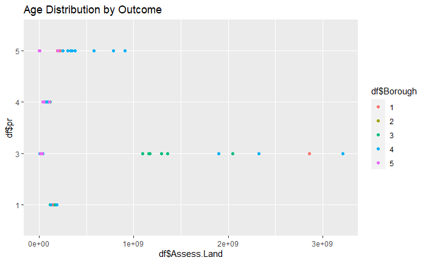

[figure not shown]

```r
ggplot(df, aes(df$Assess.Land, df$pr, colour = df$Borough)) +
  geom_point() +
  labs(title="Age Distribution by Outcome")
```

```r
library(dplyr)
library(ggplot2)
library(viridis)
par(mfrow = c(1, 3))
plot(df$Assess.Land)
plot(df$Exempt.Land)
```

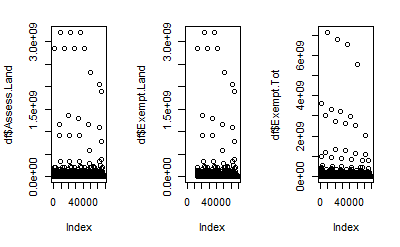

```r
plot(df$Exempt.Tot)
```

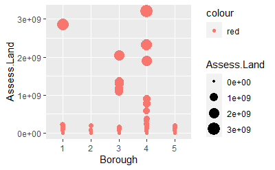

```r
ggplot(df, aes(Borough, Assess.Land, size = Assess.Land, col = "red")) +
  geom_point()
```

```r
summary(df$Assess.Land)
```

```
     Min.   1st Qu.    Median      Mean   3rd Qu.      Max.      NA's
0.000e+00 2.136e+03 4.455e+04 1.759e+06 3.918e+05 3.211e+09         1
```

```r
df$newfl <- cut(df$Num.Floors,
              breaks=c(0, 2, 5, 50, 500),
              labels=c('house', 'building', 'tall building', 'sky scraper'))
na.exclude(df$newfl)
```

[output not shown]

[output cut: 104 more lines]

```
Warning: Removed 32460 rows containing missing values (geom_point).
```

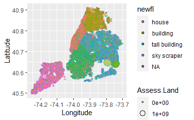

```r
df %>%
  group_by(Borough) %>%
    group_by(Num.Floors) %>%
        ggplot(aes(Longitude, Latitude, size = Assess.Land)) +
          geom_point(shape = 21, aes(alpha = 0.25, color = factor(Borough), fill = newfl)) +
          scale_color_brewer(palette = "Dark2") +
          scale_colour_discrete(na.translate = F)
```

```r
summary(df$Num.Floors)
```

```
   Min. 1st Qu.  Median    Mean 3rd Qu.    Max.
  0.000   0.000   0.000   1.022   1.000 104.000
```

```r
names(df)
```

```
 [1] "Date.Created"                          "Borough"                               "Map.Atlas"                             "Block"
 [5] "Lot"                                   "Address"                               "Street.Number"                         "Street.Name"
 [9] "Parcel.Name"                           "Agency"                                "Current.Uses"                          "Total.Area"
[13] "Open.Petroleum.Spill"                  "Govt.Clean.Up.Program"                 "Structure.Completed"                   "Number.Structures"
[17] "Total.Gross.Area.Structures"           "Ratio.Building.to.Floor.Area"          "Allowable.Building.to.Floor.Area"      "Land.Use.Category"
[21] "Community.Board"                       "Census.Tract"                          "Census.Block"                          "School.Dist"
[25] "Council.District"                      "Postcode"                              "Fire.Comp"                             "Health.Area"
[29] "Health.Ctr"                            "Police.Prct"                           "Major.Use"                             "Number.of.Easements"
[33] "Commercial.Floor.Area"                 "Residential.Floor.Area"                "Office.Floor.Area"                     "Retail.Floor.Area"
[37] "Garage.Floor.Area"                     "Storage.Floor.Area"                    "Factory.Floor.Area"                    "Other.Floor.Area"
[41] "Num.Floors"                            "Residential.Units"                     "Residential.and.Non.Residential.Units" "Lot.Front"
[45] "Lot.Depth"                             "Bldg.Front"                            "Bldg.Depth"                            "Proximity.Code"
[49] "Irr.Lot.Code"                          "Lot.Type.Code"                         "Bsmt.Code"                             "Assess.Land"
[53] "Exempt.Land"                           "Exempt.Tot"                            "Year.Alter.1"                          "Year.Alter.2"
[57] "His.Dist"                              "Landmark"                              "Condominium.Number"                    "Coordinates"
[61] "E.Designation.Number"                  "Industrial.Business.Zone"              "Zone.Dist.1"                           "Zone.Dist.2"
[65] "Overlay.1"                             "Overlay.2"                             "SP.Dist.1"                             "SP.Dist.2"
[69] "Potential.Urban.Ag"                    "Contact"                               "EDC...Occupied"                        "Pluto.Version"
[73] "Latitude"                              "Longitude"                             "BIN"                                   "BBL"
[77] "NTA"                                   "newfl"
```

```r
df$Num.Floors
```

[output not shown]

[output cut: 21 more lines]

```r
df$newfl
```

[output not shown]

[output cut: 71 more lines]

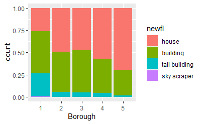

```r
filter(df, !is.na(newfl)) %>%
  ggplot() +
  geom_bar(mapping = aes(x = Borough, fill = newfl), position = "fill")
```

I discovered that Asses.Land is the actual assessed land value for Fiscal Year 2013. it makes sense that this value can get so high in NY. The exempt land is the tax value for 2013 and exempt total is the total exempt value for the year

tree

```r
library(rpart)
library(dplyr)
library(randomForest)
head(df)
```

|  | Date.Created | Borough | Map.Atlas | Block | Lot | Address | Street.Number | Street.Name | Parcel.Name | Agency | Current.Uses | Total.Area | Open.Petroleum.Spill | Govt.Clean.Up.Program | Structure.Completed | Number.Structures | Total.Gross.Area.Structures | Ratio.Building.to.Floor.Area | Allowable.Building.to.Floor.Area | Land.Use.Category | Community.Board | Census.Tract | Census.Block | School.Dist | Council.District | Postcode | Fire.Comp | Health.Area | Health.Ctr | … |
| --- | --- | --- | --- | --- | --- | --- | --- | --- | --- | --- | --- | --- | --- | --- | --- | --- | --- | --- | --- | --- | --- | --- | --- | --- | --- | --- | --- | --- | --- | --- |
| 1 | 10/10/2019 | 1 | NA | 2 | 1 | 4 SOUTH STREET | 4 | SOUTH STREET | SI FERRY TERMINAL | DOT;DSBS | FERRY TERMINAL;NO USE;WATERFRONT PROPERTY | 209215 | NA | NA | 1908 | 2 | 280000 | 1.34 | 6.5 | 7 | 101 | 9 | 1025 | 2 | 1 | 10004 | L015 | 7700 | 15 | … |
| 2 | 10/10/2019 | 1 | NA | 2 | 2 | 10 SOUTH STREET | 10 | SOUTH STREET | BATTERY MARITIME BLDG | DSBS | IN USE-TENANTED;LONG-TERM AGREEMENT;WATERFRONT PROPERTY | 191502 | NA | NA | 1900 | 1 | 158197 | 0.83 | 10.0 | 7 | 101 | 9 | 1025 | 2 | 1 | 10004 | L015 | 7700 | 15 | … |
| 3 | 10/10/2019 | 1 | NA | 2 | 3 | MARGINAL STREET | NA | MARGINAL STREET | MTA SUBSTATION | DSBS | NO USE-NON RES STRC;TRANSIT SUBSTATION | 38800 | NA | NA | 1900 | 1 | 7500 | 0.19 | 10.0 | 7 | 101 | 9 | 1 | NA | 1 | NA | NA | NA | NA | … |
| 4 | 10/10/2019 | 1 | NA | 2 | 23 | 1 PIER 6 | 1 | PIER 6 | PIER 6 | DSBS | IN USE-TENANTED;FINAL COMMITMNT-DISP;LONG-TERM AGREEMENT;NO USE;FINAL COMMITMNT-DISP | 510025 | NA | NA | 1987 | 1 | 24346 | 0.05 | 10.0 | 7 | 101 | 9 | 1025 | 2 | 1 | 10004 | L015 | 7700 | 15 | … |
| 5 | 10/10/2019 | 1 | NA | 3 | 1 | 10 BATTERY PARK | 10 | BATTERY PARK | BATTERY PARK | PARKS | PARK | 945425 | NA | NA | 1951 | 6 | 945425 | 1.00 | 0.0 | 9 | 101 | 13 | 2005 | 2 | 1 | 10004 | E010 | 7700 | 15 | … |
| 6 | 10/10/2019 | 1 | NA | 3 | 2 | PETER MINUIT PLAZA | NA | PETER MINUIT PLAZA | PETER MINUIT PLAZA/BATTERY PK | PARKS | PARK | 39900 | NA | NA | 0 | 3 | 0 | 0.00 | 0.0 | 9 | 101 | 9 | 1023 | 2 | 1 | 10004 | L015 | 7700 | 15 | … |

```r
# Determine the number of rows for training
nrow(df) * 0.75
```

```
[1] 52149.75
```

```r
# Create a random sample of row IDs
sample_rows <- sample(nrow(df), nrow(df) * 0.75)

# Create the training dataset
train <- df[sample_rows, ]

# Create the test dataset
test <- df[-sample_rows, ]

df$LUCF <- factor(df$Land.Use.Category)
model <- randomForest(LUCF ~ ., data = train)
```

```
Error in na.fail.default(list(LUCF = c(8L, 8L, 9L, 8L, 8L, 9L, 9L, 2L,  :
  missing values in object
```

```r
names(df)
```

```
 [1] "Date.Created"                          "Borough"                               "Map.Atlas"
 [4] "Block"                                 "Lot"                                   "Address"
 [7] "Street.Number"                         "Street.Name"                           "Parcel.Name"
[10] "Agency"                                "Current.Uses"                          "Total.Area"
[13] "Open.Petroleum.Spill"                  "Govt.Clean.Up.Program"                 "Structure.Completed"
[16] "Number.Structures"                     "Total.Gross.Area.Structures"           "Ratio.Building.to.Floor.Area"
[19] "Allowable.Building.to.Floor.Area"      "Land.Use.Category"                     "Community.Board"
[22] "Census.Tract"                          "Census.Block"                          "School.Dist"
[25] "Council.District"                      "Postcode"                              "Fire.Comp"
[28] "Health.Area"                           "Health.Ctr"                            "Police.Prct"
[31] "Major.Use"                             "Number.of.Easements"                   "Commercial.Floor.Area"
[34] "Residential.Floor.Area"                "Office.Floor.Area"                     "Retail.Floor.Area"
[37] "Garage.Floor.Area"                     "Storage.Floor.Area"                    "Factory.Floor.Area"
[40] "Other.Floor.Area"                      "Num.Floors"                            "Residential.Units"
[43] "Residential.and.Non.Residential.Units" "Lot.Front"                             "Lot.Depth"
[46] "Bldg.Front"                            "Bldg.Depth"                            "Proximity.Code"
[49] "Irr.Lot.Code"                          "Lot.Type.Code"                         "Bsmt.Code"
[52] "Assess.Land"                           "Exempt.Land"                           "Exempt.Tot"
[55] "Year.Alter.1"                          "Year.Alter.2"                          "His.Dist"
[58] "Landmark"                              "Condominium.Number"                    "Coordinates"
[61] "E.Designation.Number"                  "Industrial.Business.Zone"              "Zone.Dist.1"
[64] "Zone.Dist.2"                           "Overlay.1"                             "Overlay.2"
[67] "SP.Dist.1"                             "SP.Dist.2"                             "Potential.Urban.Ag"
[70] "Contact"                               "EDC...Occupied"                        "Pluto.Version"
[73] "Latitude"                              "Longitude"                             "BIN"
[76] "BBL"                                   "NTA"
```

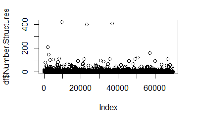

```r
library(ggplot2)
library(plyr)
library(dplyr)
plot(df$Number.Structures)
```

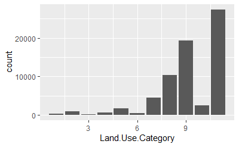

```r
ggplot(df, aes(Land.Use.Category)) +
  geom_bar()
```

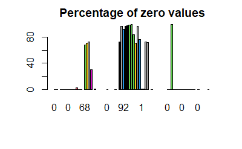

```r
zerosPercentage <- colSums(df==0)/nrow(df)*100
barplot(zerosPercentage, main = "Percentage of zero values", col = zerosPercentage, names.arg = round(zerosPercentage, 0))
```

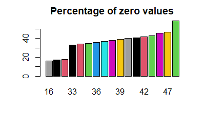

```r
greaterThan50 <-  which((colSums(df==0)/nrow(df)*100) > 50)
barplot(greaterThan50, main = "Percentage of zero values", col = greaterThan50, names.arg = round(greaterThan50, 0))
```

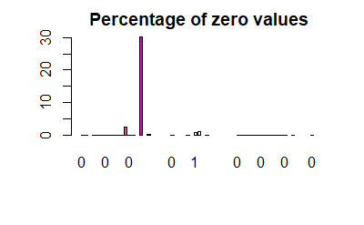

```r
unwantedColumns <- names(which((colSums(df==0)/nrow(df)*100) > 50))
cleanedDf = df[!(names(df)) %in% unwantedColumns]
zerosPercentage <- colSums(cleanedDf==0)/nrow(cleanedDf)*100
barplot(zerosPercentage, main = "Percentage of zero values", col = zerosPercentage, names.arg = round(zerosPercentage, 0))
```

```r
names(which((colSums(cleanedDf==0)/nrow(cleanedDf)*100) > 0))
```

```
[1] "Total.Area"                       "Allowable.Building.to.Floor.Area" "Community.Board"                  "Lot.Front"                        "Lot.Depth"
```

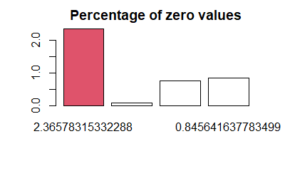

```r
col <- c("Total.Area",      "Community.Board", "Lot.Front",       "Lot.Depth")
cleanedDf = cleanedDf[!(names(cleanedDf)) %in% c("Allowable.Building.to.Floor.Area")]
barplot(zerosPercentage[col], main = "Percentage of zero values", col = zerosPercentage[col], names.arg = zerosPercentage[col])
```

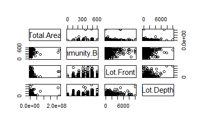

```r
plot(cleanedDf[col])
```

```r
library(dplyr)
library(ggplot2)
library(viridis)

names(df)
```

```
 [1] "Date.Created"                          "Borough"                               "Map.Atlas"                             "Block"
 [5] "Lot"                                   "Address"                               "Street.Number"                         "Street.Name"
 [9] "Parcel.Name"                           "Agency"                                "Current.Uses"                          "Total.Area"
[13] "Open.Petroleum.Spill"                  "Govt.Clean.Up.Program"                 "Structure.Completed"                   "Number.Structures"
[17] "Total.Gross.Area.Structures"           "Ratio.Building.to.Floor.Area"          "Allowable.Building.to.Floor.Area"      "Land.Use.Category"
[21] "Community.Board"                       "Census.Tract"                          "Census.Block"                          "School.Dist"
[25] "Council.District"                      "Postcode"                              "Fire.Comp"                             "Health.Area"
[29] "Health.Ctr"                            "Police.Prct"                           "Major.Use"                             "Number.of.Easements"
[33] "Commercial.Floor.Area"                 "Residential.Floor.Area"                "Office.Floor.Area"                     "Retail.Floor.Area"
[37] "Garage.Floor.Area"                     "Storage.Floor.Area"                    "Factory.Floor.Area"                    "Other.Floor.Area"
[41] "Num.Floors"                            "Residential.Units"                     "Residential.and.Non.Residential.Units" "Lot.Front"
[45] "Lot.Depth"                             "Bldg.Front"                            "Bldg.Depth"                            "Proximity.Code"
[49] "Irr.Lot.Code"                          "Lot.Type.Code"                         "Bsmt.Code"                             "Assess.Land"
[53] "Exempt.Land"                           "Exempt.Tot"                            "Year.Alter.1"                          "Year.Alter.2"
[57] "His.Dist"                              "Landmark"                              "Condominium.Number"                    "Coordinates"
[61] "E.Designation.Number"                  "Industrial.Business.Zone"              "Zone.Dist.1"                           "Zone.Dist.2"
[65] "Overlay.1"                             "Overlay.2"                             "SP.Dist.1"                             "SP.Dist.2"
[69] "Potential.Urban.Ag"                    "Contact"                               "EDC...Occupied"                        "Pluto.Version"
[73] "Latitude"                              "Longitude"                             "BIN"                                   "BBL"
[77] "NTA"                                   "newfl"
```

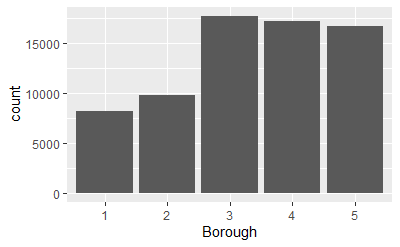

```r
df %>%
  group_by(Borough) %>%
  ggplot(aes(Borough)) +
  geom_bar()
```

```r
clr = c('yellow', 'red', 'blue', 'brown', 'green')

df %>%
  group_by(Borough) %>%
  ggplot(aes(Longitude, Latitude, col = Borough, )) +
  geom_point() +
  scale_color_viridis(option = "D")
```

```
Error: Discrete value supplied to continuous scale
```

```r
df <- read.csv("C:/Users/jeffb/OneDrive/Desktop/WSU-Spring-2022/Big Data Analitics/data-capstone-final-project/nysus.csv")
library(ggmap)
library(sp)
library(tigris)
#install.packages("devtools")
#install.packages("rworldmap")
# load library
library(rworldmap)
# get map
worldmap <- getMap(resolution = "coarse")
# plot world map

# plot data on world map
plot(worldmap, xlim = c(-74, -73), ylim = c(40, 41),
     asp = 1, bg = "lightblue", col = "black", fill = T) +
points(df$Longitude, df$Latitude,
       col = "red", cex = .01)

library(usmap)
library(ggplot2)

map <- plot_usmap(include = c("NY"))


data <- data.frame(df$Longitude, df$Latitude)
data <- data[which(!is.na(data)),]
data <- na.exclude(data)
sum(is.na(data))
new <- data[which(!is.na(data)),]
df <- na.exclude(df)
#data$Longitude <- as.data.frame(df$Longitude)
#data$Latitude <- as.data.frame(df$Latitude)
transformed_data <- usmap_transform(data)
data
plot_usmap(include = c("NY")) +
  geom_point(data = transformed_data, aes(transformed_data$df.Longitude, transformed_data$df.Latitude),
             color = "red")

plot(map,
     asp = 1, bg = "lightblue", col = "black", fill = T) +
points(df$Longitude, df$Latitude,
       col = "red", cex = .01)
plot(map,
     asp = 1, bg = "lightblue", col = "black", fill = T) +
points(data$lat, data$lon,
       col = "red", cex = .01)
plot(df$Latitude, df$Longitude)


#plot_usmap("states") +
#  geom_point(data = transformed_data,
#             aes(x = x, y = y),
#             color = "red",
#             size = 3)

#plot(map, xlim = c(-74, -73), ylim = c(40, 41),
#     asp = 1, bg = "lightblue", col = "black", fill = T) +
#points(df$Longitude, df$Latitude,
#       col = "red", cex = .01)

#df$Latitude

#devtools::install_github("dkahle/ggmap", ref = "tidyup")
#chicago <- get_stamenmap(bbox = c(left = -88.0225, bottom = 41.5949,
#                                  right = -87.2713, top = 42.0677),
#                         zoom = 11)

#ggmap(chicago)
```

[output not shown]

```r
library(maps)
library(ggplot2)

maps::map('county', region = 'new york', city = "new york", col = "#5E610B")
#map.cities(us.cities, country="NY", col = "#642EFE", cex = 0.6) # map cities recorded in us.cities to NY State
map.axes(cex.axis=0.8)
ylim(40, 41)
title(main = "New York State by Counties", xlab = "Longitude", ylab = "Latitude",
      cex.lab = 0.1)
points(-76, 43,
       col = "red", cex = .8)





#?ylim()
#?map
#ylim(40, 41) +
 # xlim(-76, -72)
#df$Latitude
#df$Longitude
```

[output not shown]

```r
df <- read.csv("C:/Users/jeffb/OneDrive/Desktop/WSU-Spring-2022/Big Data Analitics/data-capstone-final-project/nysus.csv")
str(df)

clf <- df[c("Borough", "Total.Area", "Num.Floors", "Ratio.Building.to.Floor.Area")]
clf <- na.exclude(clf)
print(is.na(clf))
nrow(clf)
nrow(df)
use <- df[]

sample_rows <- sample(nrow(clf), nrow(clf) * 0.75)
train <- clf[sample_rows, ]
test <- clf[-sample_rows, ]

normalize <- function(x) {
return ((x - min(x)) / (max(x) - min(x))) }

clf <- as.data.frame(lapply(clf[,0:4], normalize))
sample_rows <- sample(nrow(clf), nrow(clf) * 0.75)
train <- clf[sample_rows, ]
test <- clf[-sample_rows, ]
labels <- df[sample_rows, ]
train
test
test <- test[which(is.na(test) == FALSE),]
train <- train[which(is.na(train) == FALSE),]
use <- use[which(is.na(use) == FALSE),]

plot(grouping(use$Current.Uses))

knn(train = train, test = test, cl = train)
```

[output not shown]

```r
install.packages("naivebayes")
library(naivebayes)

# Build the location prediction model
df$Borough <- as.factor(df$Borough)

model <- naive_bayes(Borough ~ Open.Petroleum.Spill, data = df)

# Predict Thursday's 9am location
plot(model) #model 4 has more oil spills
model

# Predict Saturdays's 9am location
predict(locmodel, saturday9am)
```

[output not shown]